# MultiConnector: Two-Dimensional Functional Clustering Analysis

Advanced Multi-Measure Time Series Clustering with MCL Dataset

MultiConnector Development Team

2025-09-30

# Introduction

This comprehensive guide demonstrates **two-dimensional functional clustering analysis** using the **MultiConnector** package. Unlike one-dimensional analysis that focuses on a single measurement type, two-dimensional analysis simultaneously models multiple related measurements, providing richer insights into complex biological or clinical patterns.

We use the **MCL (Multiple Correspondence Longitudinal)** dataset as our case study, which contains two simultaneous measurements (**PB** and **BM**) tracked over time. This approach is particularly valuable for:

- **Multi-biomarker studies**: Analyzing multiple biomarkers simultaneously
- **Clinical monitoring**: Tracking multiple clinical parameters
- **Biological systems**: Understanding coordinated responses across measurements
- **Complex phenotyping**: Identifying patterns across multiple phenotypic measures

## Background

### Two-Dimensional Functional Clustering

Traditional clustering often treats each measurement independently, potentially missing important relationships between variables. Two-dimensional functional clustering:

1. **Preserves relationships**: Maintains correlations between measurements
2. **Reduces dimensionality**: Clusters based on joint patterns rather than individual variables
3. **Improves interpretation**: Identifies coordinated patterns across measurements
4. **Enhances stability**: Uses more information for robust clustering

### The MCL Dataset

The MCL dataset contains:

- **Subjects**: Multiple individuals tracked over time
- **Measurements**: Two coordinated measures (PB and BM)
- **Annotations**: Subject-level features (TTP, Arm, etc.)
- **Time structure**: Longitudinal observations across time points

# Package Setup and Data Loading

```
#> Dataset Overview:
```

```
#>
#> - Time series data dimensions: 1341 4
```

```
#>
#> - Annotations dimensions: 117 11
```

```
#>
#> - Unique subjects: 117
```

```
#>
#> - Measurement types: PB, BM
```

```
#>
#> - Time range: 62 1666
```

# Step 1: Data Object Creation

The first step is creating a `CONNECTORData` object that properly structures our two-dimensional time series data.

```r
# Create the main data object for two-dimensional analysis
Data <- ConnectorData(tibble(TimeSeries), tibble(Annotations))
```

```
#> ###############################
#> Data loaded...
#> Number of Observations:212
#> Number of distinct measures:2
#> Average length:6.325472
```

```r
# Display comprehensive summary
summary(Data)
```

```
#>        Length         Class          Mode
#>             1 CONNECTORData            S4
```

```r
show(Data)
```

```
#> CONNECTORData object with:
#> - Subjects: 95
#> - Measures: 2
#>
#> Lengths summary:
#>  Min. 1st Qu. Median Mean 3rd Qu. Max.
#> 3 5 7 6.647368 8 9
```

# Step 2: Initial Data Exploration

Comprehensive exploration of the two-dimensional time series structure and patterns.

## Basic Time Series Visualization

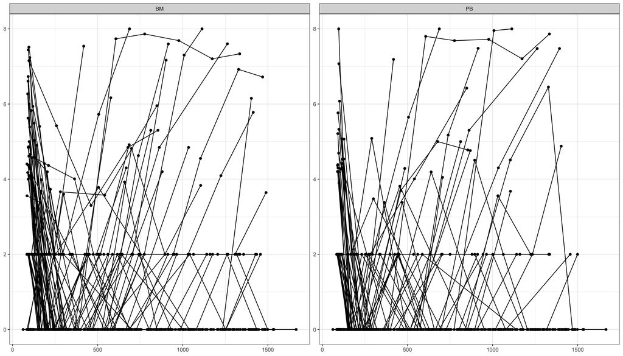

```r
# Plot 2.1: Overview of all time series (both measurements)
plot(Data)
```

This plot shows the raw time series for both PB and BM measurements, providing an initial view of the data structure and variability patterns.

## Feature-Based Exploration

```r
# Examine available features
available_features <- getAnnotations(Data)
cat("Available features for analysis:")
```

```
#> Available features for analysis:
```

```r
print(available_features)
```

```
#>  [1] "BASELINE"     "Arm"          "RND_Date"     "TTP"          "TTP_date"
#>  [6] "OS"           "OS_Date"      "PFS"          "PFS_Date"     "TimeTTPevent"
#> [11] "subjID"
```

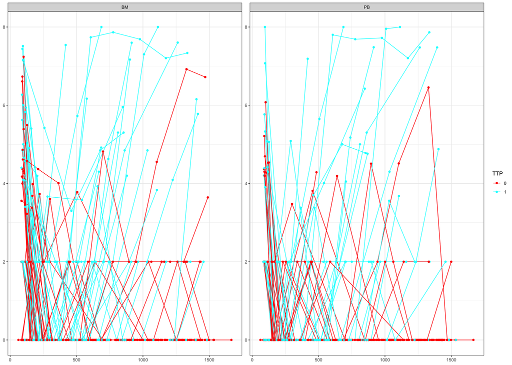

```r
# Plot 2.2: Time series colored by key features
# This helps identify potential relationships between features and temporal patterns

# TTP (Time To Progression) analysis
plot(Data, feature="TTP")
```

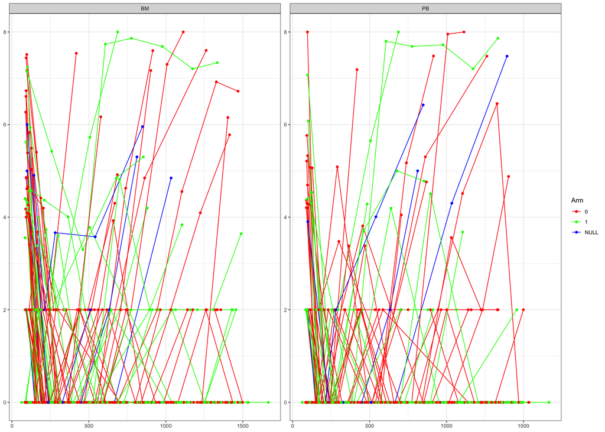

```r
# Treatment arm analysis
plot(Data, feature="Arm")
```

These visualizations reveal how different clinical features (TTP, treatment arms) may relate to the temporal patterns in our two measurements.

## Temporal Structure Analysis

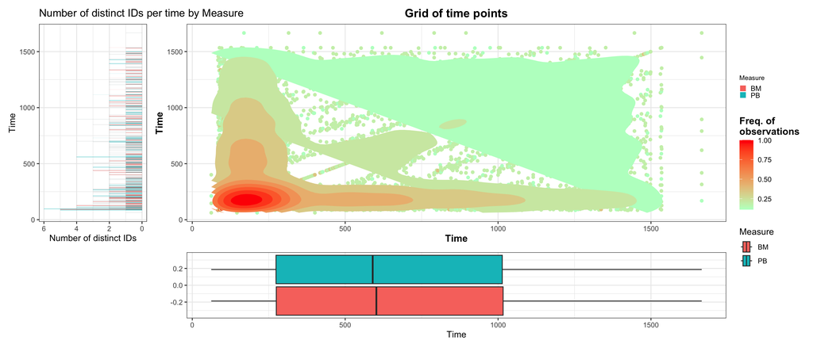

```r
# Plot 2.3: Detailed time distribution analysis
# This is crucial for two-dimensional data to understand sampling patterns

# Comprehensive time analysis
plotTimes(Data, large=TRUE)
```

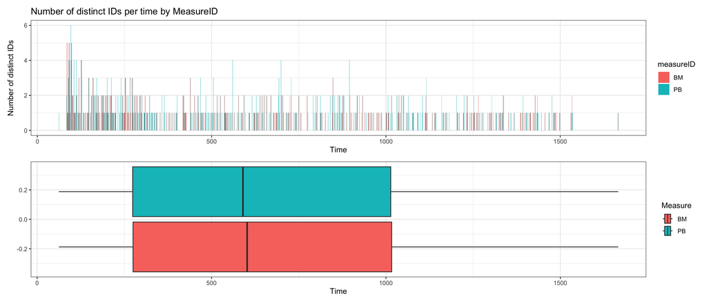

```r
# Summary time analysis
plotTimes(Data, large=FALSE)
```

The time distribution analysis is particularly important for two-dimensional data as it reveals:

- **Sampling consistency**: Whether both measurements are sampled similarly
- **Missing data patterns**: Potential gaps in either measurement
- **Temporal coverage**: The time span and density of observations

# Step 3: Spline Dimension Estimation

For two-dimensional analysis, we need to determine optimal spline dimensions for both measurements simultaneously.

```r
# Cross-validation for optimal spline basis dimensions
# This step is crucial as each measurement type may require different flexibility

cat("Estimating optimal spline dimensions...")
```

```
#> Estimating optimal spline dimensions...
```

```r
cat("\nThis process may take several minutes for two-dimensional data...")
```

```
#>
#> This process may take several minutes for two-dimensional data...
```

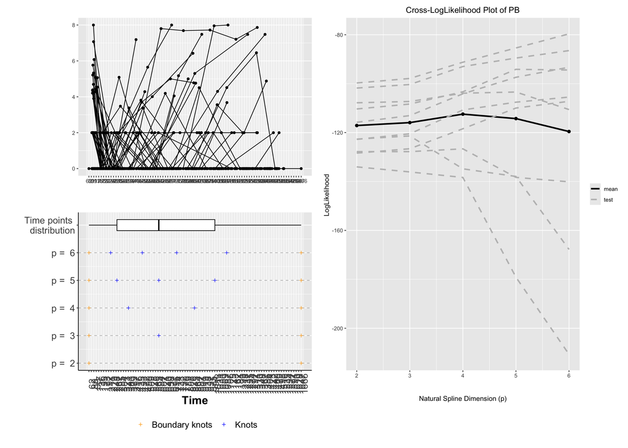

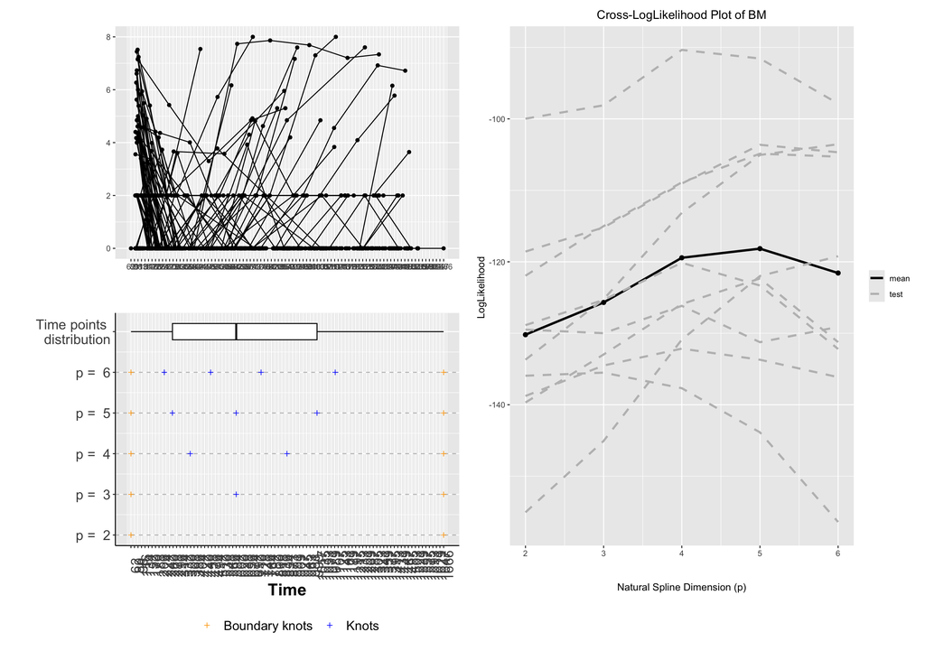

```r
# Estimate dimensions for both measurements
# Testing p values from 2 to 6 for both PB and BM
file_crosslog = system.file("Data/MCL/MCLTwoD_CrossLog.rds", package="MultiConnector")
if(file.exists(file_crosslog)){
  CrossLogLikePlot = readRDS(file_crosslog)
} else {
CrossLogLikePlot <- estimatepDimension(Data, p=2:6, cores=5)
saveRDS(CrossLogLikePlot, paste0(system.file("Data/MCL/", package="MultiConnector"), "MCLTwoD_CrossLog.rds" ) )
}

# Display the results
CrossLogLikePlot
```

The dimension estimation plot shows cross-validation results for both measurements:

- **Separate curves**: Each measurement (PB, BM) has its own optimal dimension
- **Validation pattern**: Look for clear minima or plateaus in the cross-validation curves
- **Computational cost**: Two-dimensional analysis requires more computation time

```r
# Based on the cross-validation results, select optimal dimensions
# These values would typically be chosen based on the plotted results
optimal_p <- c("PB" = 4, "BM" = 4)
```

Dimension selection rationale: - Higher p: More flexible curves, captures fine details - Lower p: Smoother curves, reduces overfitting - Optimal p: Balance between flexibility and generalization

# Step 4: Two-Dimensional Clustering Analysis

The core clustering step that simultaneously models both measurements to identify coordinated patterns.

Starting two-dimensional clustering analysis. Estimated computation time: ~5-10 minutes with 5 cores Time increases significantly with number of subjects and measurements

```r
file_cluster = system.file("Data/MCL/MCLTwoD_Clustering.rds", package="MultiConnector")
if(file.exists(file_cluster)){
  clusters = readRDS(file_cluster)
} else {
  # Perform clustering with multiple cluster numbers
# This is computationally intensive for two-dimensional data
clusters <- estimateCluster(Data,
                           G = 2:6,           # Test 2-6 clusters
                           p = optimal_p,     # Use optimal spline dimensions for both measurements
                           runs = 20,         # Multiple runs for stability
                           cores = 5)         # Parallel processing

saveRDS(clusters, paste0(system.file("Data/MCL/", package="MultiConnector"), "MCLTwoD_Clustering.rds" ) )
}
```

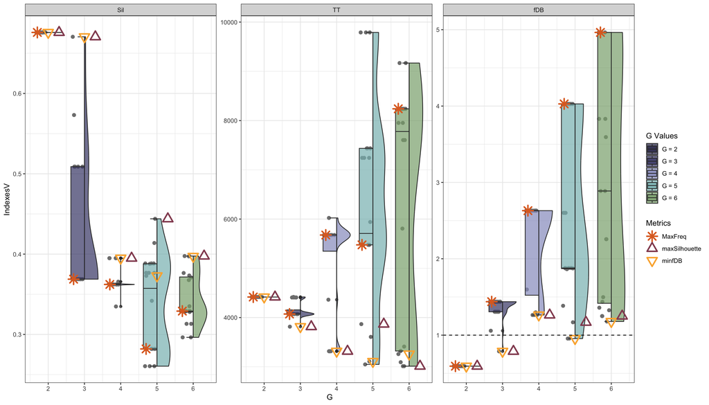

```r
# Plot clustering quality metrics
plot(clusters)
```

The clustering quality plot shows:

Key interpretations: - **Optimal G**: Look for elbow points or clear minima in fDB - **Stability**: Consistent results across runs indicate robust solutions - **Computational scaling**: Time increases with cluster number and data complexity

# Step 5: Cluster Selection and Validation

Select the optimal clustering configuration based on quality metrics.

Cluster selection:

```r
# Select optimal configuration based on quality metrics
# For demonstration, using G=3 clusters with MinfDB criterion

optimal_G <- 3
selection_criterion <- "MinfDB"

# Create the final clustered data object
ClusterData <- selectCluster(clusters, G=optimal_G, selection_criterion)
```

```
#>
#>
#> Final clustering solution:
```

```
#>
#> - Clusters identified: 3
```

```
#>
#> - Cluster labels: A, B, C
```

# Step 6: Two-Dimensional Cluster Visualization

Comprehensive visualization of clustering results across both measurements.

## Basic Cluster Visualization

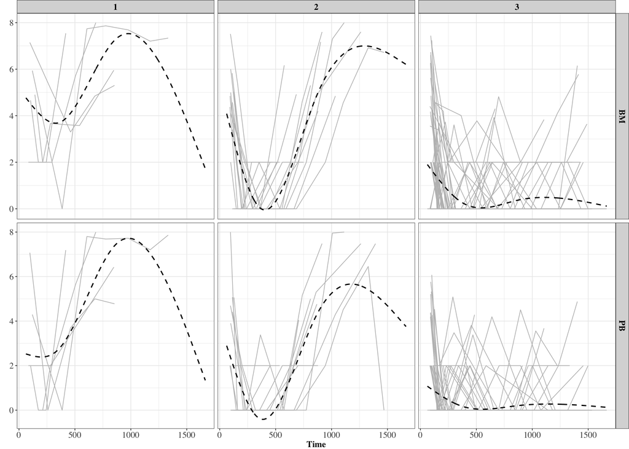

```r
# Plot 6.1: Basic cluster visualization across both measurements
plot(ClusterData)
```

This plot reveals:

- **Coordinated patterns**: How PB and BM measurements cluster together
- **Cluster separation**: Visual assessment of cluster distinctness
- **Measurement relationships**: Correlations between the two measurements within clusters

## Feature-Based Cluster Analysis

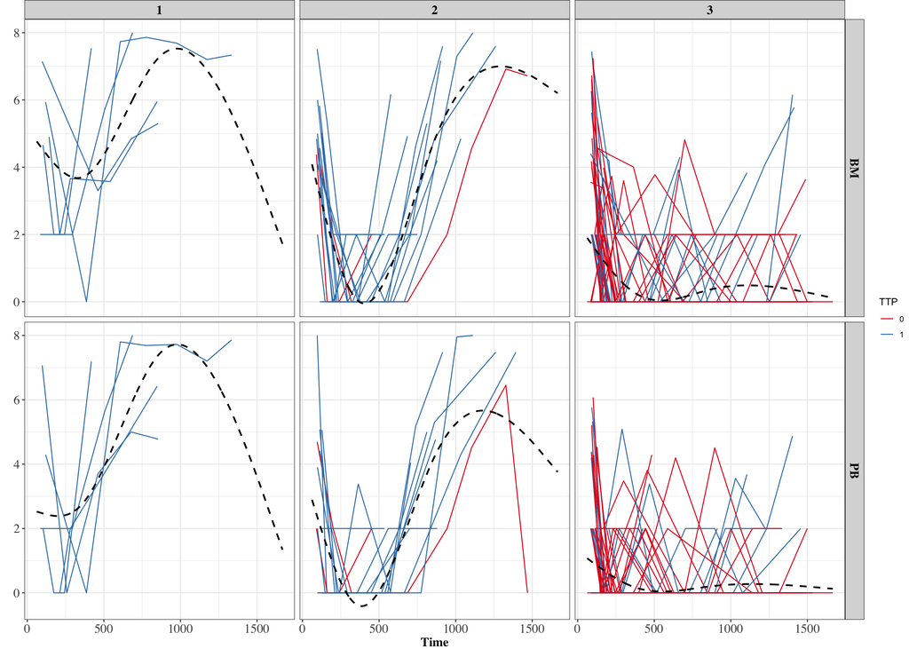

```r
# Plot 6.2: Clusters colored by clinical features
# This reveals associations between clusters and clinical characteristics

# TTP (Time To Progression) patterns
plot(ClusterData, feature="TTP")
```

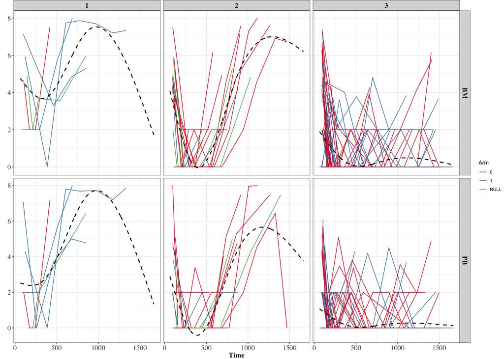

```r
# Treatment arm associations
plot(ClusterData, feature="Arm")
```

These visualizations help identify:

- **Clinical relevance**: Which clusters associate with clinical outcomes
- **Treatment effects**: Whether treatment arms segregate into clusters
- **Prognostic value**: Cluster relationships with progression times

## Cluster Composition Analysis

```r
# Analyze cluster composition across features
available_features <- getAnnotations(ClusterData)

cat("Features available for composition analysis:")
```

```
#> Features available for composition analysis:
```

```r
print(available_features)
```

```
#>  [1] "BASELINE"     "Arm"          "RND_Date"     "TTP"          "TTP_date"
#>  [6] "OS"           "OS_Date"      "PFS"          "PFS_Date"     "TimeTTPevent"
```

```r
# TTP distribution across clusters
cat("\n\n1. TTP Distribution Across Clusters:")
```

```
#>
#>
#> 1. TTP Distribution Across Clusters:
```

```r
ttp_dist <- clusterDistribution(ClusterData, feature="TTP")
print(ttp_dist)
```

```
#> # A tibble: 3 × 5
#>   TTP   `cluster 1` `cluster 2` `cluster 3` Total
#>   <chr>       <int>       <int>       <int> <dbl>
#> 1 0               0           2          55    57
#> 2 1               5          13          20    38
#> 3 TOTAL           5          15          75    95
```

```r
# Treatment arm distribution
cat("\n\n2. Treatment Arm Distribution:")
```

```
#>
#>
#> 2. Treatment Arm Distribution:
```

```r
arm_dist <- clusterDistribution(ClusterData, feature="Arm")
print(arm_dist)
```

```
#> # A tibble: 4 × 5
#>   Arm   `cluster 1` `cluster 2` `cluster 3` Total
#>   <chr>       <int>       <int>       <int> <dbl>
#> 1 0               1          10          39    50
#> 2 1               3           2          34    39
#> 3 NULL            1           3           2     6
#> 4 TOTAL           5          15          75    95
```

```r
# Display cluster assignments
cluster_assignments <- getClusters(ClusterData)
cat("\n\n3. Cluster Assignment Summary:")
```

```
#>
#>
#> 3. Cluster Assignment Summary:
```

```r
cat("\n- Total subjects clustered:", nrow(cluster_assignments))
```

```
#>
#> - Total subjects clustered: 95
```

```r
cluster_summary <- table(cluster_assignments$Cluster)
for (i in names(cluster_summary)) {
  cat("\n- Cluster", i, ":", cluster_summary[i], "subjects")
}
```

# Step 7: Advanced Subject-Level Analysis

Detailed analysis of individual subjects within the two-dimensional clustering context.

## Single Subject Analysis

```r
# Select a representative subject for detailed analysis
example_subjects <- unique(cluster_assignments$subjID)[1:3]
selected_subject <- example_subjects[1]

cat("Detailed analysis for subject:", selected_subject)
```

```
#> Detailed analysis for subject: Subject 1105
```

```r
# Comprehensive subject information
subject_info <- SubjectInfo(ClusterData, subjIDs = selected_subject)

cat("\nSubject cluster assignment:")
```

```
#>
#> Subject cluster assignment:
```

```r
cat("\n", subject_info$cluster_assignments)
```

```
#>
#>  Subject Subject 1105 belongs to Cluster 3
```

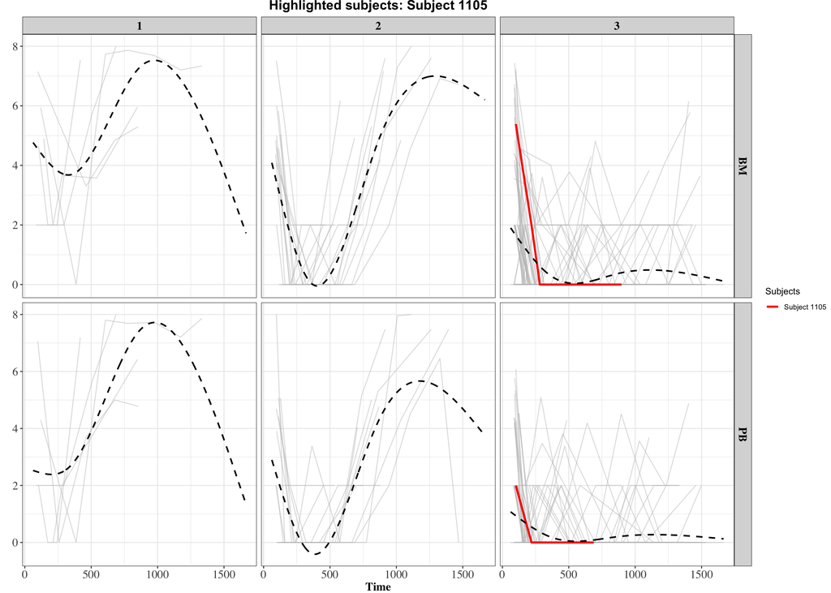

```r
# Display highlighted visualization
subject_info$highlighted_plot
```

## Multi-Subject Comparison

```r
# Compare multiple subjects across clusters
multi_subject_info <- SubjectInfo(ClusterData, subjIDs = example_subjects)

cat("Multi-subject comparison:")
```

```
#> Multi-subject comparison:
```

```r
cat("\nSubjects analyzed:", paste(example_subjects, collapse = ", "))
```

```
#>
#> Subjects analyzed: Subject 1105, Subject 1205, Subject 1206
```

```r
# Show cluster assignments
for (i in 1:nrow(multi_subject_info$cluster_table)) {
  cat("\n- Subject", multi_subject_info$cluster_table$subjID[i],
      "-> Cluster", multi_subject_info$cluster_table$cluster[i])
}
```

```
#>
#> - Subject Subject 1105 -> Cluster 3
#> - Subject Subject 1205 -> Cluster 3
#> - Subject Subject 1206 -> Cluster 2
```

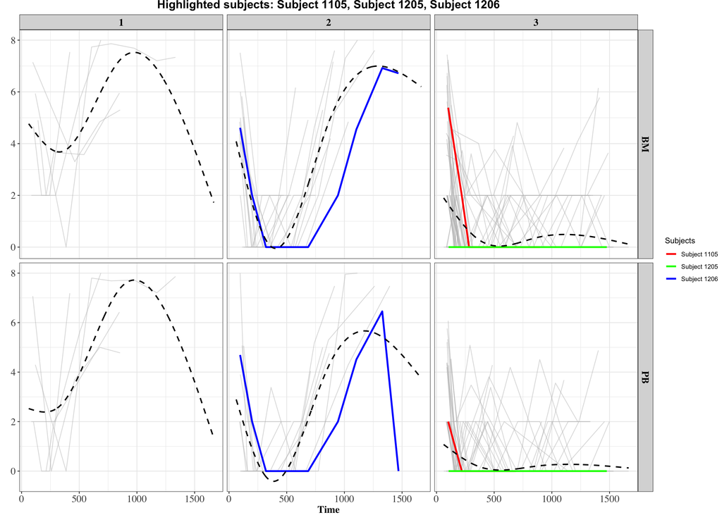

```r
# Display comparative visualization
multi_subject_info$highlighted_plot
```

# Step 8: Cluster Validation and Quality Assessment

Comprehensive validation of the two-dimensional clustering solution.

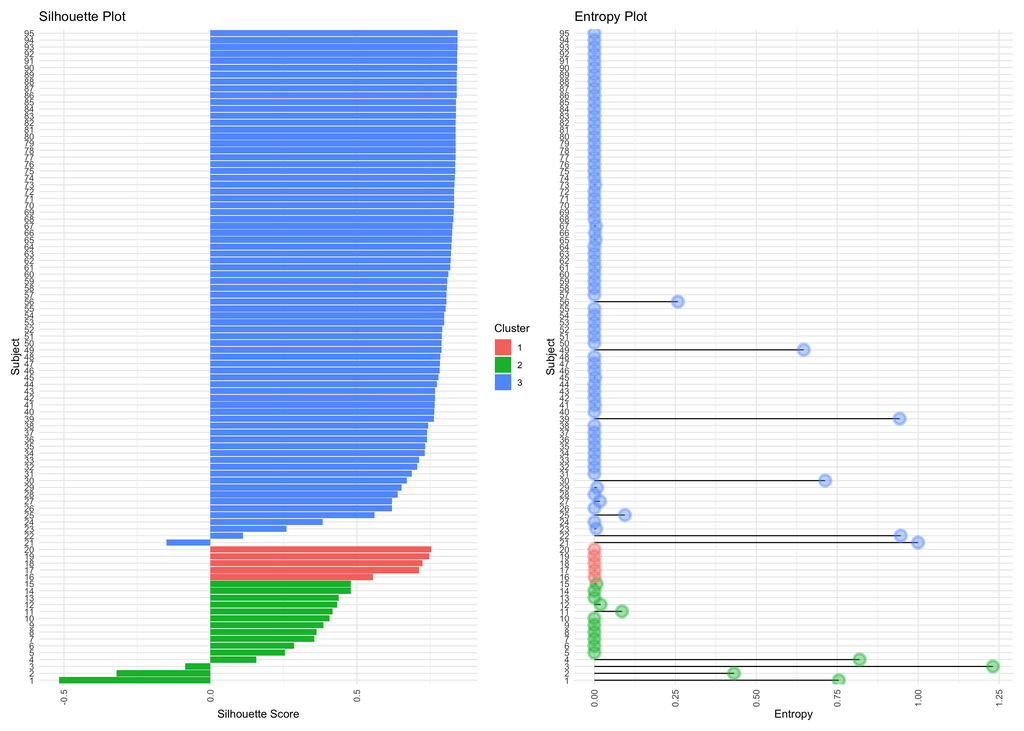

```r
validation_metrics <- validateCluster(ClusterData)

# Display validation plot
validation_metrics$plot
```

Validation Metrics Interpretation:

- Silhouette Analysis: Measures how well subjects fit their assigned clusters
  - Values near +1: Well-clustered subjects
  - Values near 0: Borderline cases
  - Negative values: Potentially misclassified subjects
- Entropy Analysis: Measures uncertainty in cluster assignments
  - Lower entropy: More confident assignments
  - Higher entropy: More uncertain assignments

```r
# Extract and summarize validation metrics
if (!is.null(validation_metrics$metrics)) {
  cat("\n\nValidation Summary:")
  print(validation_metrics$metrics)
}

# Additional quality assessment
quality_metrics <- ClusterData@TTandfDBandSil
cat("\n\nClustering Quality Metrics:")
```

```
#>
#>
#> Clustering Quality Metrics:
```

```r
print(quality_metrics)
```

```
#> # A tibble: 1 × 4
#>     fDB    TT     G   Sil
#>   <dbl> <dbl> <int> <dbl>
#> 1 0.788 3815.     3 0.671
```

# Step 9: Advanced Visualizations and Interpretations

Specialized visualizations for understanding two-dimensional clustering patterns.

## Discriminant Analysis

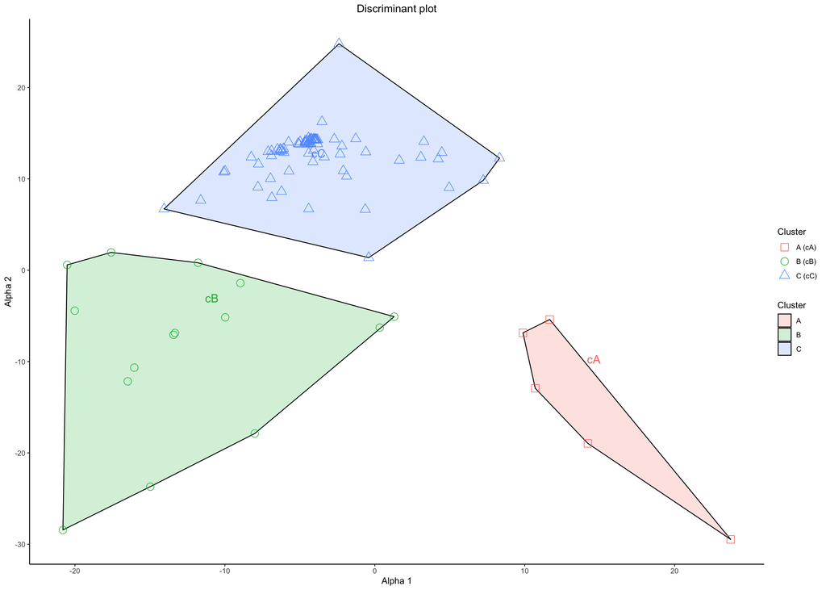

```r
# Discriminant analysis visualization

# Basic discriminant plot
discr_basic <- DiscriminantPlot(ClusterData)
discr_basic$ColCluster
```

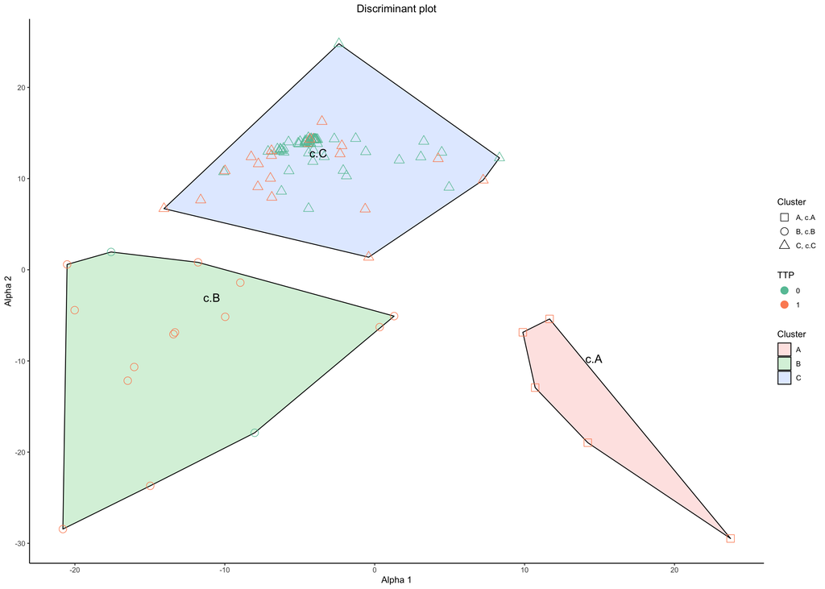

```r
# Feature-enhanced discriminant plot
discr_feature <- DiscriminantPlot(ClusterData, feature = "TTP")
discr_feature$ColFeature
```

The discriminant plots show:

- **Cluster separation**: How well clusters separate in reduced space
- **Feature relationships**: How clinical features relate to cluster structure
- **Dimensionality**: Effective dimensions needed for cluster separation

## Maximum Discrimination Analysis

Analyzing maximum discrimination functions.

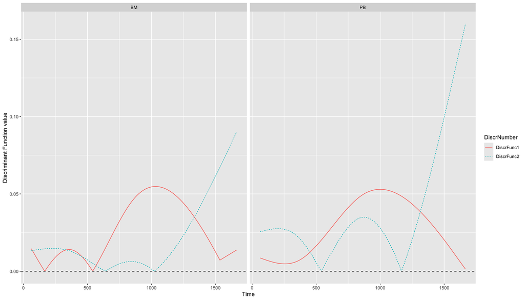

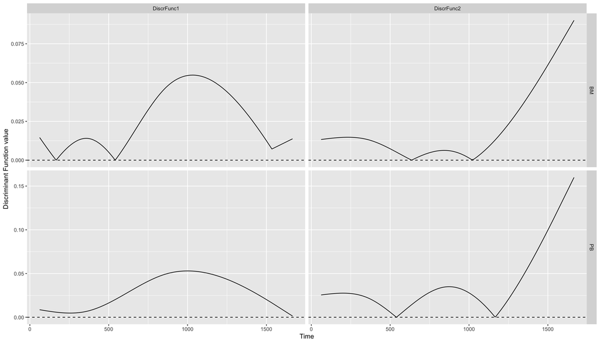

```r
# Maximum discrimination function analysis
# Identifies the most discriminative aspects of the functional data

max_discr <- MaximumDiscriminationFunction(ClusterData)
max_discr
```

This analysis reveals:

- **Discriminative time periods**: When clusters are most different
- **Measurement importance**: Which measurement (PB/BM) drives separation
- **Functional patterns**: The shapes that distinguish clusters

# Step 10: Subclustering Analysis

Advanced analysis involving subclustering of identified clusters.

Performing subclustering analysis on Cluster 3.

```r
# Get cluster assignments
cluster_assignments <- getClusters(ClusterData)

# Select subjects from cluster 3
cluster3_subjects <- cluster_assignments %>%
  filter(cluster == 3) %>%
  pull(subjID)

# Create subset data for subclustering
subData <- ConnectorData(
  tibble(TimeSeries) %>% filter(subjID %in% cluster3_subjects),
  tibble(Annotations) %>% filter(subjID %in% cluster3_subjects)
)
```

```
#> ###############################
#> Data loaded...
#> Number of Observations:150
#> Number of distinct measures:2
#> Average length:7.046667
```

```r
show(subData)
```

```
#> CONNECTORData object with:
#> - Subjects: 75
#> - Measures: 2
#>
#> Lengths summary:
#>  Min. 1st Qu. Median Mean 3rd Qu. Max.
#> 3 6 7 7.046667 9 9
```

Performing subclustering analysis. Estimated time: ~5-10 minutes

[figure not shown]

```r
file_cluster = system.file("Data/MCL/MCLTwoD_SubClustering.rds", package="MultiConnector")
if(file.exists(file_cluster)){
  subClusters = readRDS(file_cluster)
} else {
# Subcluster analysis within Cluster 3
subClusters <- estimateCluster(subData,
                              G = 2:5,           # Test fewer clusters for subset
                              p = optimal_p,     # Use same spline dimensions
                              runs = 20,         # Multiple runs for stability
                              cores = 5)

saveRDS(clusters, paste0(system.file("Data/MCL/", package="MultiConnector"), "MCLTwoD_SubClustering.rds" ) )
}

# Plot subclustering results
plot(subClusters)
```

```r
# Select optimal subclustering
subClusterData <- selectCluster(subClusters, G=3, "MinfDB")
```

Subclustering results:

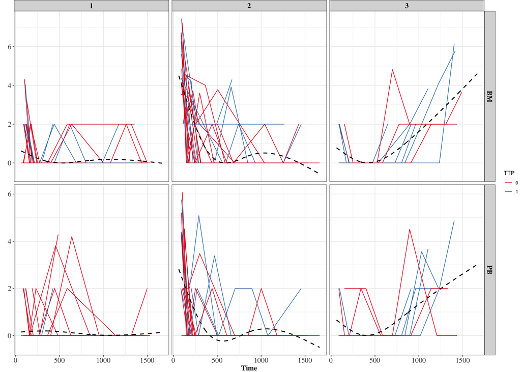

```r
# Basic subcluster visualization
plot(subClusterData, feature = "TTP")
```

```r
# Subcluster composition

subcluster_dist <- clusterDistribution(subClusterData, feature="TTP")
cat("\n\nSubcluster composition (TTP):")
```

```
#>
#>
#> Subcluster composition (TTP):
```

```r
print(subcluster_dist)
```

```
#> # A tibble: 3 × 5
#>   TTP   `cluster 1` `cluster 2` `cluster 3` Total
#>   <chr>       <int>       <int>       <int> <dbl>
#> 1 0              36          16           3    55
#> 2 1               7           7           6    20
#> 3 TOTAL          43          23           9    75
```

# Appendix: Technical Details

## Data Structure Requirements

For two-dimensional functional clustering, the data must contain:

- **subjID**: Subject identifiers (consistent across measurements)
- **measureID**: Measurement type identifiers (e.g., “PB”, “BM”)
- **time**: Time points (can vary across subjects and measurements)
- **value**: Measured values at each time point
- **Annotations**: Subject-level features for interpretation

## Algorithm Details

The two-dimensional clustering approach:

1. **Spline fitting**: Fits natural cubic splines to each measurement separately
2. **Joint modeling**: Combines spline coefficients across measurements
3. **Clustering**: Groups subjects based on joint spline patterns
4. **Validation**: Assesses quality using multi-dimensional metrics

## Parameter Selection Guidelines

- **Spline dimensions (p)**: Start with 3-5, adjust based on cross-validation
- **Cluster numbers (G)**: Test 2-8 clusters, select based on quality metrics
- **Runs**: Use 20-50 runs for stability assessment
- **Cores**: Use 4-8 cores for optimal performance

*This comprehensive guide demonstrates the power of two-dimensional functional clustering for complex longitudinal data analysis. The MultiConnector package provides robust tools for identifying coordinated patterns across multiple measurements, enabling deeper insights into biological and clinical processes.*